# PCA (principal component analysis)

```python
pip install -U kaleido==0.2.1
```

```python
##Import necessary libraries
import numpy as np ##numpy is used to provide numerical opeartions,since we can write it directly we use this.
import pandas as pd ## pandas are used for data manipulation and creating dataframes(understands the sturtured data)
from sklearn.decomposition import PCA ## Imported scikit-learn ,it's main tool for performing principal component analysis
from sklearn.preprocessing import StandardScaler##ensures all features have the same scale(mean=0,standard deviation=1), a requriement for PCA
import matplotlib.pyplot as plt## to present the graphs and its overall growth or loss
```

so above we are importing the libraries which is necessary to find PCA[Principal Component Analysis] we are using Scikit-learn in this code Scikit-learn is a popular library in Python that makes it easy to use machine learning algorithms and tools. It’s like a toolbox for data science and machine learning. Instead of writing complex code for algorithms from scratch, scikit-learn provides pre-built, optimized functions that you can use directly. we used following in-bulits 1.numpy:numpy is used to play with numbers and arrays for the numerical operation we need numpy and it also helps for data manipulation 2.pandas:A library to handle data in table format (like Excel). It makes working with rows and columns easy. 3.PCA from scikit-learn: This is the tool we’ll use to perform Principal Component Analysis. 4.StandardScaler: A helper to make all the features in the data equally important by standardizing them (more on this later). 5.matplotlib.pyplot: A library for making graphs to visualize data.

```python
## Creating or loading data
data=pd.read_csv(r"C:\Users\Shreya\Downloads\retail_waste_management_dataset.csv")
data
```

|  | Store_ID | Daily_Customers | Daily_Sales_Units | Unsold_Inventory | Expired_Products | Returned_Items | Perishable_Products_Ratio | Avg_Storage_Days | Recycled_Waste_Weight_kg | Disposal_Cost_INR |
| --- | --- | --- | --- | --- | --- | --- | --- | --- | --- | --- |
| 0 | 1088 | 295 | 1501 | 376 | 53 | 44 | 0.49 | 37 | 24.21 | 3247.45 |
| 1 | 1073 | 422 | 1751 | 193 | 9 | 9 | 0.41 | 48 | 20.07 | 4089.90 |
| 2 | 1010 | 193 | 1667 | 172 | 36 | 34 | 0.79 | 11 | 23.69 | 4786.94 |
| 3 | 1019 | 220 | 1246 | 296 | 68 | 83 | 0.79 | 6 | 29.97 | 4989.88 |
| 4 | 1068 | 303 | 599 | 467 | 78 | 116 | 0.76 | 19 | 15.14 | 5183.22 |
| ... | ... | ... | ... | ... | ... | ... | ... | ... | ... | ... |
| 195 | 1052 | 140 | 373 | 169 | 28 | 15 | 0.87 | 25 | 17.44 | 6589.38 |
| 196 | 1043 | 330 | 400 | 159 | 84 | 93 | 0.88 | 1 | 18.34 | 6386.55 |
| 197 | 1027 | 417 | 733 | 471 | 19 | 143 | 0.71 | 22 | 24.90 | 6513.71 |
| 198 | 1023 | 206 | 489 | 44 | 84 | 10 | 0.39 | 13 | 20.34 | 4087.96 |
| 199 | 1066 | 420 | 1960 | 72 | 96 | 145 | 0.84 | 17 | 14.75 | 6204.20 |

200 rows × 10 columns

```python
df=pd.DataFrame(data)
df
```

|  | Store_ID | Daily_Customers | Daily_Sales_Units | Unsold_Inventory | Expired_Products | Returned_Items | Perishable_Products_Ratio | Avg_Storage_Days | Recycled_Waste_Weight_kg | Disposal_Cost_INR |
| --- | --- | --- | --- | --- | --- | --- | --- | --- | --- | --- |
| 0 | 1088 | 295 | 1501 | 376 | 53 | 44 | 0.49 | 37 | 24.21 | 3247.45 |
| 1 | 1073 | 422 | 1751 | 193 | 9 | 9 | 0.41 | 48 | 20.07 | 4089.90 |
| 2 | 1010 | 193 | 1667 | 172 | 36 | 34 | 0.79 | 11 | 23.69 | 4786.94 |
| 3 | 1019 | 220 | 1246 | 296 | 68 | 83 | 0.79 | 6 | 29.97 | 4989.88 |
| 4 | 1068 | 303 | 599 | 467 | 78 | 116 | 0.76 | 19 | 15.14 | 5183.22 |
| ... | ... | ... | ... | ... | ... | ... | ... | ... | ... | ... |
| 195 | 1052 | 140 | 373 | 169 | 28 | 15 | 0.87 | 25 | 17.44 | 6589.38 |
| 196 | 1043 | 330 | 400 | 159 | 84 | 93 | 0.88 | 1 | 18.34 | 6386.55 |
| 197 | 1027 | 417 | 733 | 471 | 19 | 143 | 0.71 | 22 | 24.90 | 6513.71 |
| 198 | 1023 | 206 | 489 | 44 | 84 | 10 | 0.39 | 13 | 20.34 | 4087.96 |
| 199 | 1066 | 420 | 1960 | 72 | 96 | 145 | 0.84 | 17 | 14.75 | 6204.20 |

200 rows × 10 columns

```python
df.head(5) # to take as a sample
```

|  | Store_ID | Daily_Customers | Daily_Sales_Units | Unsold_Inventory | Expired_Products | Returned_Items | Perishable_Products_Ratio | Avg_Storage_Days | Recycled_Waste_Weight_kg | Disposal_Cost_INR |
| --- | --- | --- | --- | --- | --- | --- | --- | --- | --- | --- |
| 0 | 1088 | 295 | 1501 | 376 | 53 | 44 | 0.49 | 37 | 24.21 | 3247.45 |
| 1 | 1073 | 422 | 1751 | 193 | 9 | 9 | 0.41 | 48 | 20.07 | 4089.90 |
| 2 | 1010 | 193 | 1667 | 172 | 36 | 34 | 0.79 | 11 | 23.69 | 4786.94 |
| 3 | 1019 | 220 | 1246 | 296 | 68 | 83 | 0.79 | 6 | 29.97 | 4989.88 |
| 4 | 1068 | 303 | 599 | 467 | 78 | 116 | 0.76 | 19 | 15.14 | 5183.22 |

```python
df.info #to give a descriptive information of the data to understand and work
```

[output not shown]

[output cut: 25 more lines]

```python
df.isnull().sum()# to check whether what are missing values
```

```
Store_ID                     0
Daily_Customers              0
Daily_Sales_Units            0
Unsold_Inventory             0
Expired_Products             0
Returned_Items               0
Perishable_Products_Ratio    0
Avg_Storage_Days             0
Recycled_Waste_Weight_kg     0
Disposal_Cost_INR            0
dtype: int64
```

```python
features=['Daily_Customers','Daily_Sales_Units']
X=df[features]
```

Daily_Customers= indicates the demand Daily_Sales_Units= shows the profit of the business. the performance of the business the reasons of choosing the data was to whether customer volume directly impacts sales, and PCA can tell us the direction of strongest variance (i.e., trend)

```python
##Standarlizing the data
# PCA is affected by scale, so we normalize the data to have mean=0 and variance=1
scaler=StandardScaler()
X = df[['Daily_Customers', 'Daily_Sales_Units']]
data_std = scaler.fit_transform(X)
```

Why Standardize?

Features (columns) might have different scales (e.g., one column could have values from 0–100, another from 0–1). PCA works better if all features are on the same scale. What happens here?

fit_transform calculates the mean and standard deviation of each column and adjusts the values so they have: A mean of 0. A standard deviation of 1. Now, all the columns are equally important.

What is PCA doing?

fit figures out the directions (principal components). transform changes the data to use these new directions. After this, data_pca contains the transformed data with only 2 columns.

```python
# Step 4: Compute the covariance matrix
# The covariance matrix helps understand how features vary together
cov_matrix = np.cov(data_std, rowvar=False)
cov_matrix
```

```
array([[ 1.00502513, -0.08504224],
       [-0.08504224,  1.00502513]])
```

```python
# Step 6: Transform data to principal component space
# We multiply the standardized data by eigenvectors to get the new representation
pca = PCA(n_components=2)   # 2D PCA
X_pca = pca.fit_transform(data_std)
# Explained variance
print("Explained Variance Ratio:", pca.explained_variance_ratio_)
```

```
Explained Variance Ratio: [0.54230851 0.45769149]
```

.This tells us how much of the original data's information (variance) is captured by each principal component.

fit finds principal directions (axes of highest variance).

transform projects original data into this new space.

Explained Variance Ratio shows how much information (variance) each component captures.

```python
# Step 5: Compute eigenvalues and eigenvectors
# Eigenvalues tell us how much variance each principal component explains
# Eigenvectors define the direction of the new feature space
eigenvalues, eigenvectors = np.linalg.eig(cov_matrix)
eigenvalues ,eigenvectors
```

```
(array([0.91998289, 1.09006737]),
 array([[-0.70710678,  0.70710678],
        [-0.70710678, -0.70710678]]))
```

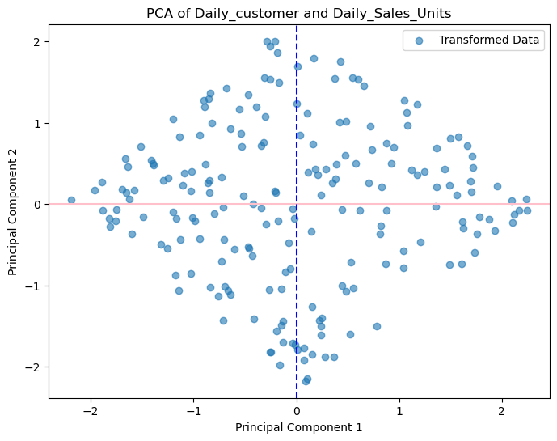

```python
## Visualizing the Transformed Data
plt.figure(figsize=(8, 6))
plt.scatter(X_pca[:, 0], X_pca[:, 1], alpha=0.6, label="Transformed Data")
plt.axhline(0, color='pink', linestyle='solid')
plt.axvline(0, color='blue', linestyle='dashed')
plt.xlabel("Principal Component 1")
plt.ylabel("Principal Component 2")
plt.title("PCA of Daily_customer and Daily_Sales_Units")
plt.legend()
plt.show()
```

What are we doing?

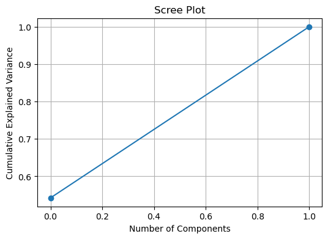

```python
pca = PCA()
pca.fit(data_std)
plt.figure(figsize=(6,4))
plt.plot(np.cumsum(pca.explained_variance_ratio_), marker='o')#cumsum is to show how much cumulative variance is explained by the principal components.
plt.title("Scree Plot")
plt.xlabel("Number of Components")
plt.ylabel("Cumulative Explained Variance")
plt.grid(True)
plt.show()
```

It shows how much variance is retained as components increase.

```python
import plotly.express as px # to make graph more readable and to make it good by adding colors

pca = PCA(n_components=2)
X_pca = pca.fit_transform(data_std)

# Step 5: Create a DataFrame for Plotly
pca_df = pd.DataFrame(data=X_pca, columns=['PC1', 'PC2'])
pca_df['Store_ID'] = data['Store_ID']  # Optional: Use for hover info

# Step 6: Plot interactive scatter
fig = px.scatter(
    pca_df,
    x='PC1',
    y='PC2',
    hover_data=['Store_ID'],
    title='🧮 Interactive PCA of Daily Customers vs Daily Sales Units',
    labels={'PC1': 'Principal Component 1', 'PC2': 'Principal Component 2'},
    color='PC1',  # Adds color scale
    template='plotly_dark'
)
fig.show()
fig.write_image("pca_plot.png")
```

[interactive chart not shown]

Conclusion:

```python
pip show kaleido
```